# Columbia River Spring Chinook Marine Survival: Synthesis of Multi-Stage SEM Deliverables

Consolidated Results Across Objectives 1–5

Author

Lisa Crozier et al.

Published

November 6, 2026

# 1 Objective 1 & 2: Ecosystem Drivers & Multi-Model Variable Importance

## 1.1 Overview

Model selection across candidate single-indicator structural equation models (SEMs) evaluated the relative influence of coastal Northern California Current (NCC) and Gulf of Alaska (AK) drivers on early marine survival (SAR). Multi-model inference via Akaike weights ($w_i$) was calculated across all statistically valid models ($p(\chi^2) \ge 0.05$, $\text{CFI} \ge 0.80$, $\text{SRMR} \le 0.10$, $\text{AGFI} \ge 0.80$) following baseline exclusions (`sablefishAK_biomass4plus` and `pollockGOA_SSB_lag1`).

## 1.2 Figure 1: Relative Variable Importance across Ecosystem Indicators

Relative variable importance ($w_i$) across all ecosystem indicators meeting the $\max(w_i) \ge 0.05$ threshold, comparing sequential mediation (DAG 1A) and direct growth mediation (DAG 1B) topologies across the 24-year complete dataset and 19-year expanded series.

[figure not shown]

Figure 1: Relative variable importance (Akaike weights) across candidate functional ecosystem indicators.

# 2 Objective 3: Direct vs. Modulated Predation Topologies

## 2.1 Overview

To address counter-intuitive positive relationships between raw predator abundance and salmon survival, candidate predators were evaluated under an effective predation framework ($P_{\text{eff}}$):
$$P_{\text{eff}} = P_{\text{norm}} \cdot \text{SST}_{\text{gate}} \cdot (1 - \text{AltPrey}_{\text{gate}})$$
where thermal spatial overlap ($\text{SST}$) and alternative forage buffering ($\text{AltPrey}$) were scaled with a 0.2 baseline floor to prevent complete zero-multiplication.

## 2.2 Table 3: Effective Predation ($P_{\text{eff}}$) Model Comparisons

Comparison of nominal predator biomass models versus top-ranked modulated $P_{\text{eff}}$ formulations. Shaded green cells indicate models where thermal gating and/or alternative prey buffering restored ecologically coherent top-down control ($\beta < 0$, $p \le 0.05$) with substantial AIC improvement ($\Delta\text{AIC} \le -2.0$).

Table 1

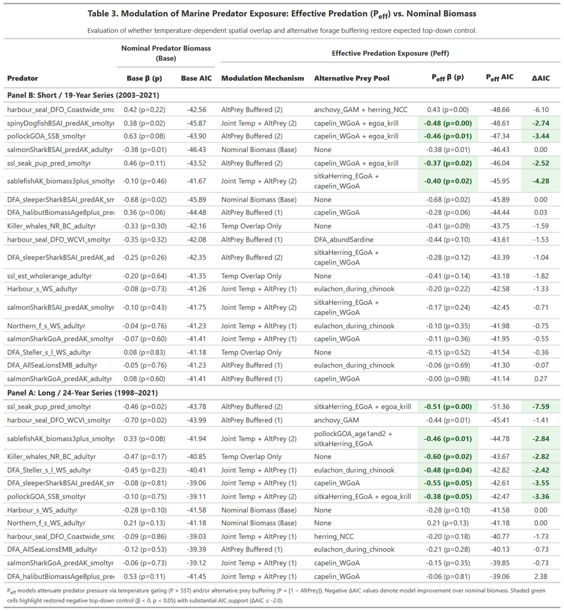

Modulation of marine predator exposure: Nominal biomass vs. effective predation exposure (Peff).

# 3 Objective 4: Multi-Basin Life-Stage Bottlenecks

## 3.1 Overview

The life-stage hypothesis ladder was tested sequentially across the 24-year complete dataset (1998–2021) to evaluate the spatial and temporal bounds of survival bottlenecks:

1. **Single-Arena (Early Marine NCC Only):** $\text{SAR} \sim \text{Growth}_{\text{NCC}} + \text{CPUE}_{\text{NCC}}$
2. **Dual-Arena (+ Subarctic Alaska Marine):** $\text{SAR} \sim \text{Growth}_{\text{NCC}} + \text{CPUE}_{\text{NCC}} + \text{Prey}_{\text{AK}} + P_{\text{ocean\_eff}}$
3. **Triple-Arena (+ Adult Columbia River Pinnipeds):** $\text{SAR} \sim \text{Growth}_{\text{NCC}} + \text{CPUE}_{\text{NCC}} + \text{Prey}_{\text{AK}} + P_{\text{ocean\_eff}} + P_{\text{river\_adult}}$

## Table 4: Single-, Dual-, and Triple-Arena Model Comparisons

Table 2

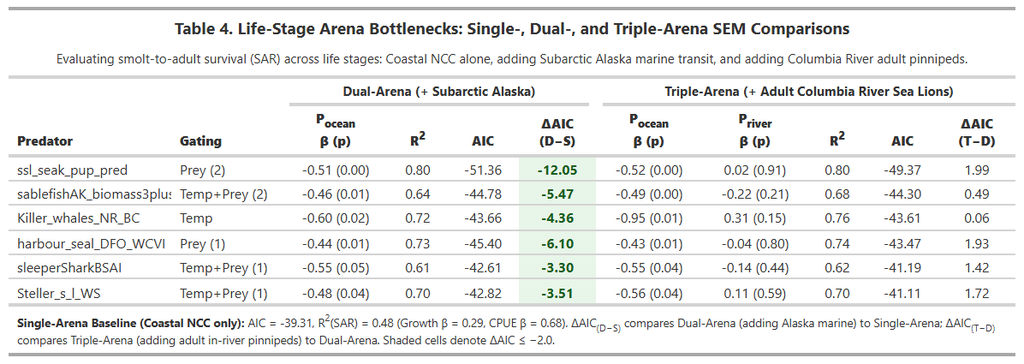

Life-stage arena bottlenecks: Single- (coastal baseline), Dual- (adding subarctic marine), and Triple-Arena (adding adult in-river pinnipeds) SEM comparisons.

# 4 Final Pruned Latent Structural Equation Models

## 4.1 Candidate 2: Subarctic Groundfish Piscivore (Sablefish Age 3+)

Final pruned structural model retaining both coastal early marine and subarctic marine stages.

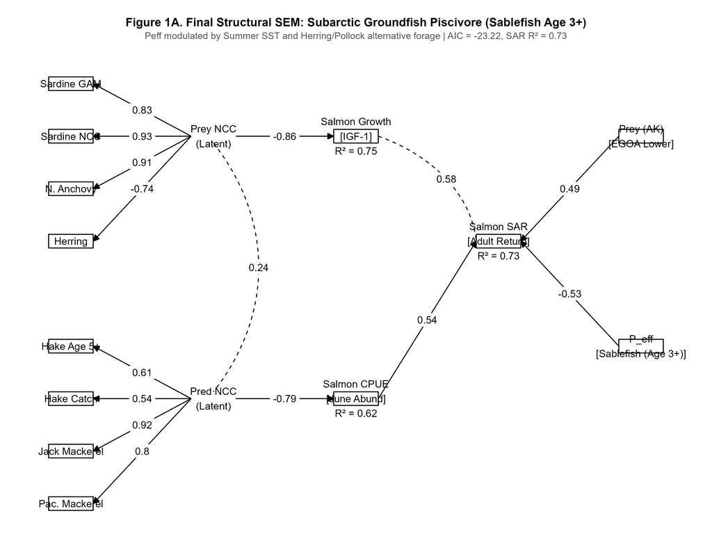

Figure 2: Final pruned structural equation model: Sablefish Age 3+ Peff model (AIC = -23.22, SAR R² = 0.73).

## 4.2 Candidate 4: Subarctic Apex Shark (Sleeper Shark)

Final pruned structural model retaining top-down subarctic apex shark predation.

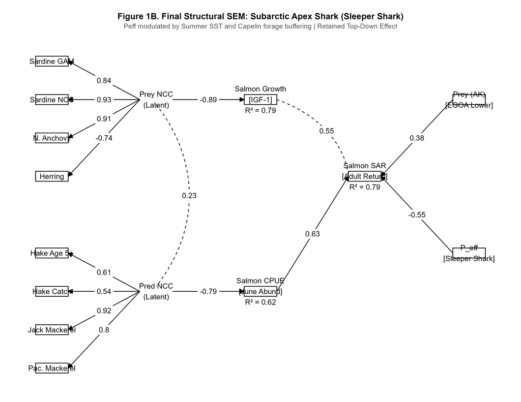

Figure 3: Final pruned structural equation model: Sleeper Shark Peff model.

## 4.3 Candidate 1 / Baseline: Coastal-Only Pruned Architecture

Pruned architecture resulting when candidate subarctic marine predators drop out ($p \ge 0.05$).

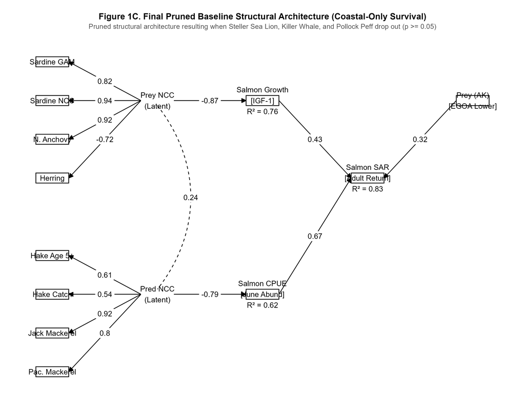

Figure 4: Final pruned baseline structural architecture (Coastal-only survival; AIC = -21.58, SAR R² = 0.83).

# 5 Supplementary Material

Full numerical compilation of cumulative Akaike weights ($w_i$) across all candidate indicators, including those falling below the main text $\max(w_i) \ge 0.05$ plotting threshold.

Table 3

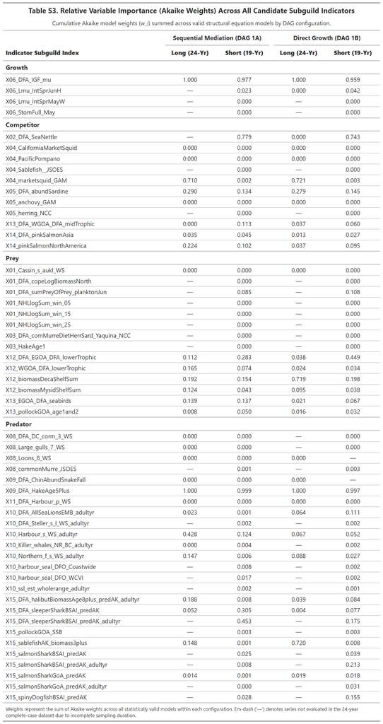